# Séance 2 : Régression Linéaire - BONUS

### Regression en quantile

Un autre moyen de fixer un seuil est d’utiliser les quantiles. Pour bien comprendre, lorsqu’on estime la regression où $Y_t$ est expliqué par $X_t$, on estime en fait l’impact de l’ensemble des chocs de $X_t$ (l’ensemble de la distribution statistique de $X_t$) sur l’ensemble des chocs de $Y_t$.

En revanche, on peut imaginer des variables qui ne réagissent qu’à certains chocs, notamment très négatifs ou très positif (qui sont rares mais de forte amplitude), mais qui ne réagissent pas aux chocs “normaux”, qui sont fréquents mais de faible amplitude. On peut donc décomposer $X_t$ en quantiles pour regarder l’impact de différents quantiles en suivant la même méthode avec les seuils :

$$\begin{align*}
Y_t = a_0 + &\beta_1 X_t . I(X_t \le Q(X_t, 0.1)) + \\ &\beta_2
X_t . I(X_t \ge Q(X_t, 0.9))+ \\ &\beta_3 X_t +\varepsilon_t
\end{align*}$$

Ici, $\beta_1$ va mesurer l’impact de $X_t$ sur $Y_t$ lorsque $X_t$ est dans sa queue de distribution gauche, c’est-à-dire pendant les chocs extrêmement négatifs (en général, ça représente les périodes de crises de $X_t$). $\beta_2$ capture l’impact des chocs extrêmement positifs de $X_t$ (pendant les périodes de boom - ou de surréaction positive - parfois associé à de la spéculation) sur $Y_t$. Enfin, $\beta_3$ capture l’effet de $X_t$ sur $Y_t$ dans les autres périodes, donc les périodes “normales”.

```r
donnees_quantiles <- donnees %>%
  mutate(extr_neg = ifelse(unemp <= quantile(unemp, 0.1), 1, 0 ))%>% # dummy prend valeur 1 pendant périodes extrêmement négatives de dunemp
  mutate(extr_pos = ifelse(unemp >= quantile(unemp, 0.9), 1, 0)) # dummy prend valeur 1 pendant périodes extrêmement positives de dunemp
reg_quantile_x <- feols(inflation ~ unemp +  unemp : extr_neg + unemp : extr_pos, data=donnees_quantiles)
etable(reg_quantile_x)
```

```
                     reg_quantile_x
Dependent Var.:           inflation

Constant           7.894*** (1.424)
unemp            -0.5827** (0.1954)
unemp x extr_neg     -1.603 (1.270)
unemp x extr_pos   -0.1600 (0.1593)
________________ __________________
S.E. type                       IID
Observations                    109
R2                          0.17055
Adj. R2                     0.14685
---
Signif. codes: 0 '***' 0.001 '**' 0.01 '*' 0.05 '.' 0.1 ' ' 1
```

Ici, on peut voir un effet différencié en fonction des queues de distribution : effet négatif et significatif sur les taux “normaux”, et pas d’effet lors des périodes extrêmes (positives ou négatives)

D’autres spécifications sont totalement possibles avec des quantiles. Notamment, plutôt que de regarder l’impact de la distribution de $X_t$, on peut regarder l’impact de la distribution de $Y_t$ afin de regarder si les chocs de $X_t$ tendant à être plus ou moins transmis pendant les périodes extrêmes de $Y_t$

$$\begin{equation}
Q_y(\tau|Y_t) = a_0(\tau) + \beta (\tau) X_t + \varepsilon(\tau)
\end{equation}$$
Ici, $Q_y(\tau|Y_t)$ représente $Y_t$ conditionnel, c’est-à-dire évalué au quantile $\tau$ de sa distribution. Pour chaque quantile, on obtient une constante, un coefficient et un résidu différent.

```r
require(quantreg)
quantiles <- seq(0.1, 0.9, 0.1)
reg_quantile_y <- rq(inflation ~ unemp, tau=quantiles, data=donnees)
summary(reg_quantile_y)
```

```
Call: rq(formula = inflation ~ unemp, tau = quantiles, data = donnees)

tau: [1] 0.1

Coefficients:
            coefficients lower bd upper bd
(Intercept)  1.77270      0.56545  3.84529
unemp       -0.38883     -0.89483 -0.22030

Call: rq(formula = inflation ~ unemp, tau = quantiles, data = donnees)

tau: [1] 0.2

Coefficients:
            coefficients lower bd upper bd
(Intercept)  3.54469     -0.00411  3.67762
unemp       -0.45445     -0.51200  0.00799

Call: rq(formula = inflation ~ unemp, tau = quantiles, data = donnees)

tau: [1] 0.3

Coefficients:
            coefficients lower bd upper bd
(Intercept)  3.51110      1.79333  5.00127
unemp       -0.34540     -0.52934 -0.12200

Call: rq(formula = inflation ~ unemp, tau = quantiles, data = donnees)

tau: [1] 0.4

Coefficients:
            coefficients lower bd upper bd
(Intercept)  4.36140      3.21748  5.50944
unemp       -0.36967     -0.53472 -0.21765

Call: rq(formula = inflation ~ unemp, tau = quantiles, data = donnees)

tau: [1] 0.5

```

[output cut: 25 more lines]

```
tau: [1] 0.8

Coefficients:
            coefficients lower bd upper bd
(Intercept) 13.38613     10.33023 15.91960
unemp       -0.93261     -1.18271 -0.66465

Call: rq(formula = inflation ~ unemp, tau = quantiles, data = donnees)

tau: [1] 0.9

Coefficients:
            coefficients lower bd upper bd
(Intercept) 16.12010     13.90711 26.23575
unemp       -0.99550     -1.65016 -0.54592
```

Le plus intéressant est de regarder l’évolution des coefficients dans les quantiles de $Y_t$

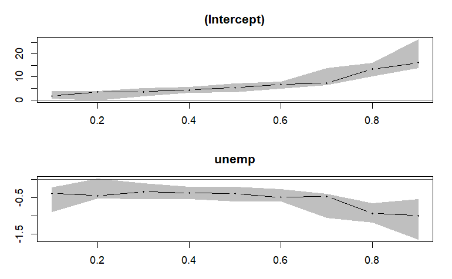

```r
summary(reg_quantile_y) %>% plot(ols=F)
```

Le graphique représente l’évolution des coefficients en fonction des quantiles de $Y_t$. On peut voir qu’à priori, l’effet négatif d’une hausse du taux de chômage est plus fort lorsque le niveau d’inflation est dans ses valeurs extrêmement positive (à partir du 8ème décile, dans la queue droite de sa distribution). En revanche, pour vérifier que les coefficients diffèrent bien entre les queues de distribution et l’effet à la médiane, il faut effectuer des tests statistiques plus formels (le test de Wald en l’occurence).